# Homework 6 Responses

Zeyi Han, Shubhi Sharma, Margaret Swift

2020-03-25

## Exercise 1

*Interpret the main effects and interactions in this model.*

I’ve renamed the parameters used in the JAGS model to make it a bit easier to interpret. From the density and trace plots, it is clear that all four chains converged rather quickly. The intercept is negative here, while both the CO2 treatment and the tree’s diameter affect growth rates positively. The interaction of both CO2 treatment and diameter, however, is slightly negative, hinting at something more going on beneath the surface of this analysis. As we will see later on, there is a Simpson’s paradox underlying these data, and this hidden group effect might be causing the seemingly competing contributions of CO2 treatment and diameter versus their interaction.

```
##                  Mean          SD        2.5%       97.5%
## co2treat   0.63183951 0.103805140  0.52596641  0.73973770
## diameter   0.15029284 0.005179550  0.14684304  0.15434530
## inax      -0.02557967 0.005524224 -0.03139945 -0.02000295
## intercept -4.05046708 0.096439111 -4.12248091 -3.98701435
```

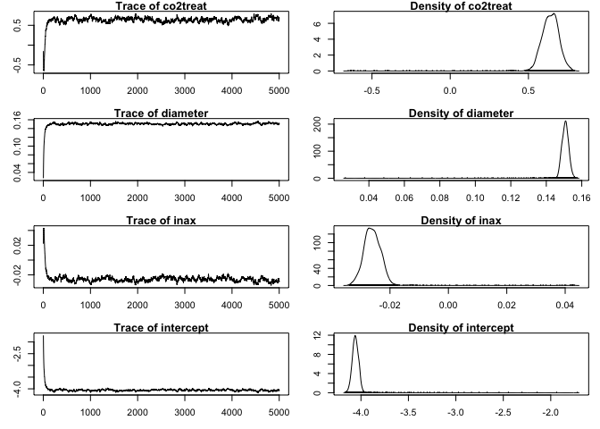

## Exercise 2

*Run the model again, including `nfert` (nitrogen fertilization) in addition to other variables. Interpret its effect.*

Results from the model below. With the addition of the `nfert` predictor, the density outputs from JAGS remain the same for the CO2 treatment, tree diameter, and their interaction. The MCMC chain for nitrogen fertilization is much noisier, but likewise the chain converges quickly. It seems that nitrogen fertilization has negatively affected the growth rates of these trees. This is a curious result, as usually one would think that adding fertilizer would help with plant growth. Perhaps there is some confounding variable we are missing here–maybe added nitrogen is encouraging competitive growth of weedy species nearby, or too much nitrogen is being added and burning the trees’ roots. This is an interesting finding, regardless, and could be investigated further.

```
##                  Mean          SD        2.5%       97.5%
## co2treat   0.63567618 0.101628760  0.52433240  0.73612892
## diameter   0.15271597 0.005266141  0.14867557  0.15657733
## inax      -0.02604245 0.005396771 -0.03149397 -0.02006569
## intercept -4.06338110 0.098148337 -4.13027158 -3.99174223
## nfert     -0.21956706 0.023546343 -0.26406778 -0.17347344
```

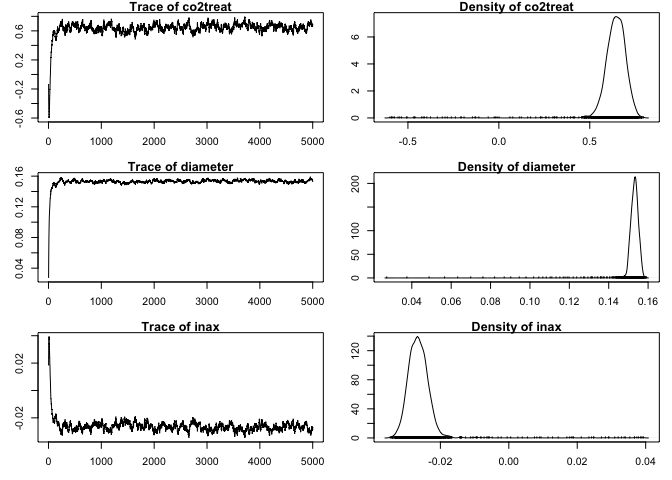

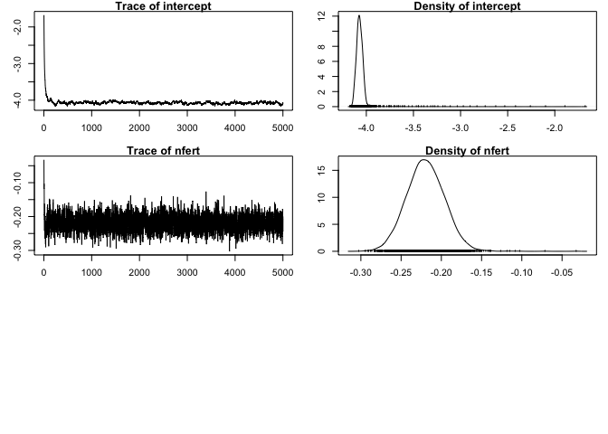

## Exercise 4

*Interpret the main effects and interactions in this hierarchical model. How does it compare with the model that included only fixed effects? Think about the role of variation between individuals versus within individuals. Speculate on why the differences.*

## Appendix

```r
#----------------------------------------------------------------------------
# LOADING
knitr::opts_chunk$set(echo=FALSE, eval=TRUE, cache=TRUE)
pacman::p_load(ggplot2, rjags)
source('../clarkfunctions2020.R')
Rcpp::sourceCpp('../cppFns.cpp')
# any libraries and data here

#----------------------------------------------------------------------------
# FUNCTIONS
# put functions here

# Here is a data set:
data   <- read.table('../dataFiles/FACEtrees.txt',header=T)
data$y <- log(data[,'dnow']) # growth rate -- log of diameter now
tmp    <- model.frame(y ~ j + i + diam*trt, data)
ij     <- apply( cbind(tmp$j, tmp$i), 1, paste0, collapse='-') # tree, plot
X      <- model.matrix(y ~ diam*trt, tmp)
y      <- tmp$y
n      <- length(y)

# Here is model object for jags, which is written to a file `growthFixed.txt`:
cat( "model{
    for(i in 1:n){
      y[i]  ~ dnorm(mu[i],tau)
      mu[i] <- intercept + diameter*X[i,2] + co2treat*X[i,3] + inax*X[i,4]
    }

    tau     ~ dgamma(0.001,0.001)
    sigma   <- sqrt(1/tau)

    intercept ~ dnorm(0.0,1.0E-06)
    diameter ~ dnorm(0.0,1.0E-06)
    co2treat ~ dnorm(0.0,1.0E-06)
    inax ~ dnorm(0.0,1.0E-06)
  }
    ", fill=T, file="growthFixed.txt"
)

# Here I run the model and look at the output:
treeData   <- list(y = y, X = X, n = n )
varNames <- c('intercept', 'diameter', 'co2treat', 'inax')
parNames <- c(varNames, 'sigma')
parInit <- function(){ list(sigma = runif(1,0,1)) }
growFit <- invisible(jags.model(data=treeData, file="growthFixed.txt"))
update(growFit)
growFit <- coda.samples(growFit, variable.names=varNames, n.iter=5000)

tmp <- summary(growFit)
betaFixed <- cbind( tmp$statistics[,1:2], tmp$quantiles[,c('2.5%','97.5%')] )
print(betaFixed)
par(mar=c(3,3,1,1))
plot( as.mcmc(growFit) )
#----------------------------------------------------------------------------
## EXERCISE 2

# DATA
tmp    <- model.frame(y ~ j + i + diam*trt + nfert, data)
ij     <- apply( cbind(tmp$j, tmp$i), 1, paste0, collapse='-') # tree, plot
X      <- model.matrix(y ~ diam*trt + nfert, tmp)
y      <- tmp$y
n      <- length(y)

# JAGS
cat( "model{
    for(i in 1:n){
      y[i]  ~ dnorm(mu[i],tau)
      mu[i] <- intercept + diameter*X[i,2] + co2treat*X[i,3] + nfert*X[i,4] + inax*X[i,5]
    }

    tau     ~ dgamma(0.001,0.001)
    sigma   <- sqrt(1/tau)

    intercept ~ dnorm(0.0,1.0E-06)
    diameter ~ dnorm(0.0,1.0E-06)
    co2treat ~ dnorm(0.0,1.0E-06)
    nfert ~ dnorm(0.0,1.0E-06)
    inax ~ dnorm(0.0,1.0E-06)
  }
    ", fill=T, file="growthFixed.txt"
)
treeData   <- list(y = y, X = X, n = n )
variable.names <- c("intercept","diameter","co2treat","nfert","inax")
parNames <- c(variable.names,'sigma')
parInit <- function(){ list(sigma = runif(1,0,1)) }
growFit <- jags.model(data=treeData, file="growthFixed.txt")
update(growFit)
growFit <- coda.samples(growFit, variable.names=variable.names, n.iter=5000)

tmp <- summary(growFit)
betaFixed <- cbind( tmp$statistics[,1:2], tmp$quantiles[,c('2.5%','97.5%')] )
print(betaFixed)
par(mar=c(3,3,1,1))
plot( as.mcmc(growFit) )
#----------------------------------------------------------------------------
## EXERCISE 5

data   <- read.table('../dataFiles/FACEtrees.txt',header=T)
data$y <- log(data[,'dnow'])                                   # growth rate
tmp2    <- model.frame(y ~ j + i + diam*trt + nfert, data)
ij     <- apply( cbind(tmp2$j, tmp2$i), 1, paste0, collapse='-') # tree, plot
X      <- model.matrix(y ~ diam*trt + nfert, tmp2)
y      <- tmp2$y
n      <- length(y)
tn    <- sort(unique(ij))   # tree labels
ix    <- match(ij,tn)       # random effect by tree
ntree <- max(ix)            # no. trees

cat( "model{
    for(i in 1:n){
      y[i]  ~ dnorm(mu[i],tau)
      mu[i] <- b1 + b2*X[i,2] + b3*X[i,3] + b4*X[i,4] + b5*X[i,5] +
               a1[ix[i]] + a2[ix[i]]*X[i,2] + a3[ix[i]]*X[i,3] + a4[ix[i]]*X[i,4] +  a5[ix[i]]*X[i,5]
    }
    for(j in 1:ntree){
      a1[j]  ~ dnorm(0.0,tau1)
      a2[j]  ~ dnorm(0.0,tau2)
      a3[j]  ~ dnorm(0.0,tau3)
      a4[j]  ~ dnorm(0.0,tau4)
      a5[j]  ~ dnorm(0.0,tau5)
    }
    tau1   ~ dgamma(0.001,0.001)    #RE precision intercept
    sigma1 <- 1/sqrt(tau1)          #RE variance intercept
    tau2   ~ dgamma(0.001,0.001)    #RE precision diam
    sigma2 <- 1/sqrt(tau2)          #RE variance diam
    tau3   ~ dgamma(0.001,0.001)    #RE precision diam
    sigma3 <- 1/sqrt(tau3)          #RE variance diam
    tau4   ~ dgamma(0.001,0.001)
    sigma4 <- sqrt(1/tau4)
    tau5   ~ dgamma(0.001,0.001)
    sigma5 <- sqrt(1/tau5)
    tau    ~ dgamma(0.001,0.001)
    sigma  <- sqrt(1/tau)

    b1 ~ dnorm(0.0,1.0E-06)
    b2 ~ dnorm(0.0,1.0E-06)
    b3 ~ dnorm(0.0,1.0E-06)
    b4 ~ dnorm(0.0,1.0E-06)
    b5 ~ dnorm(0.0,1.0E-06)
    }
    ", fill=T,file="growthRE2.txt" )
treeData   <- list(y = y, X = X, ix = ix, ntree = ntree, n = n)
growthRE2 <- jags.model(data=treeData, file="growthRE2.txt")
update(growthRE2)
growthRE2 <- coda.samples(growthRE2,
                         variable.names=c("b1","b2","b3","b4","b5",
                                          "a1","a2","a3","a4","a5", "sigma1","sigma2","sigma3","sigma4","sigma5"), n.iter=5000)
tmp2 <- summary(growthRE2)
par(mar=c(3,3,1,1))
betaRE2 <- cbind( tmp2$statistics[,1:2], tmp2$quantiles[,c('2.5%','97.5%')] )
# Here are parameter estimates:
cnames <- colnames(growthRE2[[1]])
a1     <- which(startsWith(cnames, 'a1'))
a2     <- which(startsWith(cnames, 'a2'))
a3     <- which(startsWith(cnames, 'a3'))
a4     <- which(startsWith(cnames, 'a4'))
a5     <- which(startsWith(cnames, 'a5'))
bg     <- which(startsWith(cnames, 'b'))
sg     <- which(startsWith(cnames, 's'))

bgibbs <- growthRE2[[1]][,bg]
sgibbs <- growthRE2[[1]][,sg]

beta2  <- apply(bgibbs,2, mean)

alpha2 <- cbind( apply(growthRE2[[1]][,a1],2, mean),
                apply(growthRE2[[1]][,a2],2, mean),
                apply(growthRE2[[1]][,a3],2, mean),
                apply(growthRE2[[1]][,a4],2, mean),
                apply(growthRE2[[1]][,a5],2, mean))
```